# Part II - Exploring Ford GoBike System Data

## by Heiler Santiago Gómez Prieto

## Investigation Overview

In this notebook we will have the results of the review of several of the variables that influence the operation of the Ford GoBike program. Among the most important conclusions we will find the behavior of the number of trips per day (and per hour of the day), the factors that can affect the duration of the trips and the importance of the location of the stations in the number of trips made by zone.

## Dataset Overview

The Ford GoBike System Data dataset contains information on bicycle trips made as part of the Ford GoBike program. This dataset includes travel information in terms of

- Location (Start and end points)
- Service duration
- Client identification (Sex, Birth year, Bike share for all trip)

## Number of trips per day in February 2019

Regarding the characteristics of the schedules in which the trips are made, there is a certain weekly seasonality in the number of trips that are made per day, since in general fewer trips are made on weekends than during the week

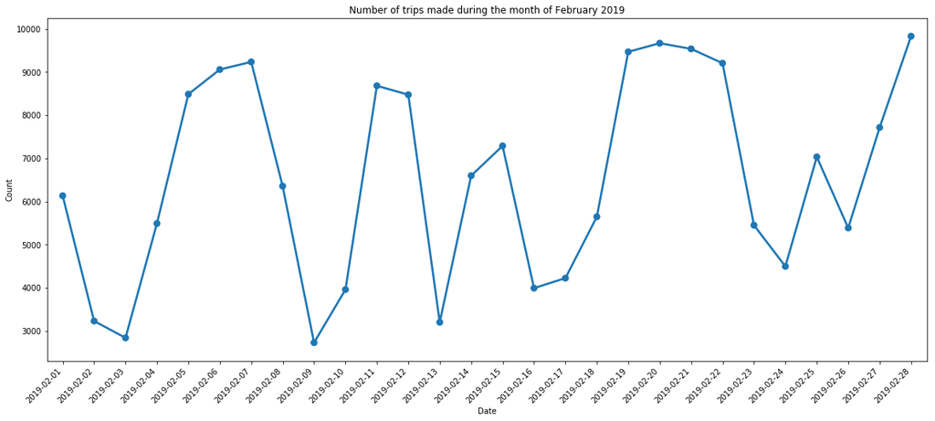

## Trips in "rush hours"

There is a quite interesting relationship between the number of trips made and the time of day, where the largest number of trips coincides precisely with what is usually the "rush hour" in the offices (arrival and departure times | 8 and 17)

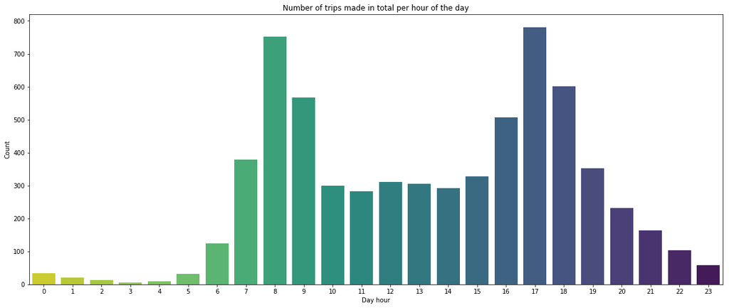

## Trip duration depending on...

The trip durations present a relationship with the age of the user, the older, the shorter the duration of the trips, and vice versa; in addition to having a certain relationship with the sex of the people.

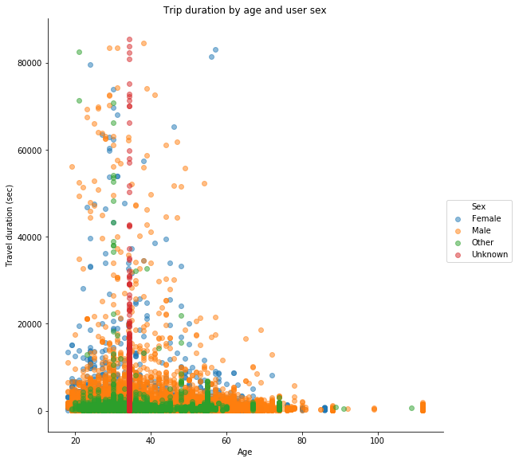

## Station location and their impact in number of trips

The number of trips that are made in the program depends mainly on things such as the location of the stations and the day/time in which the trips are made, since it is very dependent on the needs of the population near the stations of the program. (need to move close to your area of residence or in rush hours)

Make this Notebook Trusted to load map: File -> Trust Notebook

[interactive chart not shown]